# Generating Synthetic Data from a Simple Biophysical Simulation

*Author: Kyriacos Nicolaou (kyriakosn24@gmail.com)*  
*Updated: 12th of December, 2024*

## Introduction

We want to fit Log-Gaussian Cox Process (LGCP) model to capture the underlying biophysical characteristics of particle "puncta" generated in a simulated cellular environment. To achieve this, we construct a stochastic biophysical model of particles diffusing within a crowded cell. The presence of intracellular crowders creates spatial heterogeneity in particle density, and our goal is to evaluate whether an LGCP model can recover this heterogeneity from the simulated particle locations obtained over multiple simulation runs.

## Model

We simulate particle diffusion within a two-dimensional representation of the cell interior. The cell is modeled as the region between two concentric circles: the inner circle represents the cell nucleus, and the outer circle represents the cell membrane. Particles are introduced at the nuclear boundary at a specified production rate. After their introduction, they diffuse through the cytosol with a given diffusion coefficient and are eventually degraded at a certain rate.

To mimic the complexity of the intracellular environment, we include a number of randomly placed small discs ("crowders") in the cytosol. These crowders represent obstacles that cause particles to reflect upon contact, thereby creating non-uniform particle distributions over time. By analyzing these distributions with an LGCP model, we aim to infer the underlying spatial heterogeneity introduced by the crowders.

## Simulation class

The code for the simulation can be found in the file simulation.py which is in the same folder (notebooks/). In the file we define the simulation class whose objects are initialized with the parameters of the simulation. These parameters are the cell radius, the nucleus radius, the radius of each crowder, the mean density of crowders, the diffusion coeficient of particles, their total production rate and their degradation rate and a the timestep.

# Import

- we import the Simulation class from the simulation file
- and other helpfull libraries

```python
import numpy as np
import matplotlib.pyplot as plt
from simulation import Simulation, Circle, Point

# For saving the synthetic data
import geopandas as gpd
import shapely
import rasterio
import pickle
```

## Setup simulation parameters

```python
# SETUP UP SETTINGS
CELL_RADIUS = 1
NUCLEUS_RADIUS = 1/3
CROWDER_RADIUS = 0.1
MEAN_DENSITY_OF_CROWDERS = 20
PRODUCTION_RATE = 100
DEGRADATION_RATE = 1
DIFFUSION_COEFFICIENT = 0.3
DT = 0.001
```

First we will calculate some quantities relevant to our simulation

```python
mean_free_length = 1/(2*CROWDER_RADIUS*MEAN_DENSITY_OF_CROWDERS) if MEAN_DENSITY_OF_CROWDERS> 0 else np.inf
print(f"mean void distance :{mean_free_length}")

decay_length = np.sqrt(DIFFUSION_COEFFICIENT/DEGRADATION_RATE)
print(f"decay length from nucleus :{decay_length}")

diffusion_step = np.sqrt(DIFFUSION_COEFFICIENT*DT)
print(f"diffusion length :{diffusion_step}")

correltion_time =  1/(DEGRADATION_RATE)
print(f"correltion_time   :{correltion_time}")

mean_number_of_particles = PRODUCTION_RATE/DEGRADATION_RATE
print(f"mean number of particles :{mean_number_of_particles}")

hpp_mean_density = mean_number_of_particles/(np.pi*(CELL_RADIUS**2 - NUCLEUS_RADIUS**2))
print(f"mean density of the processes is a homogeneous Poisson process :{hpp_mean_density}")
print(f"ln(mean density) of hpp :{np.log(hpp_mean_density)}")
```

```
mean void distance :0.25
decay length from nucleus :0.5477225575051661
diffusion length :0.017320508075688773
correltion_time   :1.0
mean number of particles :100.0
mean density of the processes is a homogeneous Poisson process :35.80986219567645
ln(mean density) of hpp :3.578223335795075
```

Lets set up a simulation object

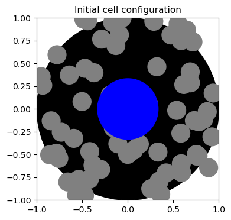

```python
# create simulation object
sim = Simulation(CELL_RADIUS,
                 NUCLEUS_RADIUS,
                 CROWDER_RADIUS,
                 MEAN_DENSITY_OF_CROWDERS,
                 PRODUCTION_RATE,
                 DEGRADATION_RATE,
                 DIFFUSION_COEFFICIENT,
                DT)

# plot initial state of simulation
fig, ax = plt.subplots(figsize=(4, 4))
ax.set_title("Initial cell configuration", size = 11)
sim.plot(ax)
```

Now we would like to run it for enough time to reach temporal stationarity

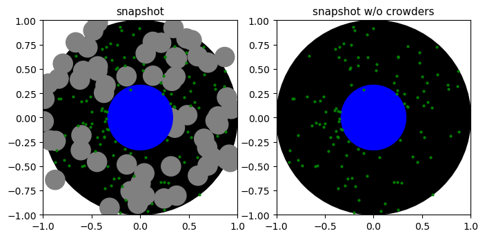

```python
# we run the simulagtion for 10000 steps which correspond to a time of 10000 steps is about 10 times the correlation time
sim.simulate(10000)

fig, axes = plt.subplots(1,2,figsize=(8, 4))

sim.plot(axes[0], plot_cell=True, plot_nucleus=True, plot_crowders=True, plot_particles=True)
axes[0].set_title("snapshot",size = 11)


sim.plot(axes[1], plot_cell=True, plot_nucleus=True, plot_crowders=False, plot_particles=True)
axes[1].set_title("snapshot w/o crowders",size = 11)

plt.show()
```

From the left plot above: we see how the crowders exclude the particles and on the plot on the right, by hidding the crowders we see that there are hotspots and cold spots of particles .

## Now we will run a collection of simulations and keep their final state as realizations of the generating process of particles

```python
n_simulations = 9

simulations = []

N_TIMESTEPS = 10000

for sim_i in range(n_simulations):
    sim = sim = Simulation(CELL_RADIUS, NUCLEUS_RADIUS,
                           CROWDER_RADIUS,MEAN_DENSITY_OF_CROWDERS,
                           PRODUCTION_RATE,DEGRADATION_RATE,DIFFUSION_COEFFICIENT, DT)

    sim.simulate(N_TIMESTEPS)
    simulations.append(sim)
```

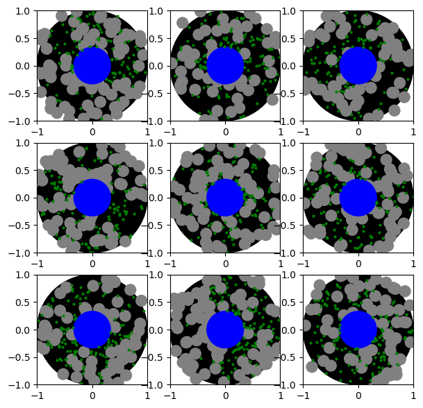

```python
fig, axes = plt.subplots(3,3,figsize=(7, 7))

for sim,ax in zip(simulations,axes.flatten()):
    sim.plot(ax, plot_cell=True, plot_nucleus=True, plot_crowders=True, plot_particles=True)

plt.show()
```

we can save the simulation objects by pickling them

```python
# Save the simulation objects results
with open("../data/synthetic_data/diffusion_in_crowded_enviroment/synthetic_data.pkl", 'wb') as file:
    pickle.dump(simulations, file)
```

## Creating predictor maps, contours and other auxilary objects for the spatial analysis

```python
simulation_spatial_data = []

for sim in simulations:
    simulation_spatial_data.append( {"simulation object": sim})
```

```python
class SpatialData():
    def __init__(self,x,y):
        self.x = x
        self.y = y

    def shift(self,dx,dy):
        self.x = [i_x + dx for i_x in self.x ]
        self.y = [i_y + dy for i_y in self.y ]

angles = np.linspace(0,2*np.pi,30)
cell_contour_x = CELL_RADIUS*np.cos(np.linspace(0,2*np.pi,30))
cell_contour_x[-1] = cell_contour_x[0]
cell_contour_y = CELL_RADIUS*np.sin(np.linspace(0,2*np.pi,30))
cell_contour_y[-1] = cell_contour_y[0]

cell_contour = SpatialData(cell_contour_x,cell_contour_y)

nucleus_contour_x = NUCLEUS_RADIUS*np.cos(np.linspace(0,2*np.pi,30))
nucleus_contour_x[-1] = nucleus_contour_x[0]
nucleus_contour_y = NUCLEUS_RADIUS*np.sin(np.linspace(0,2*np.pi,30))
nucleus_contour_y[-1] = nucleus_contour_y[0]

nucleus_contour = SpatialData(nucleus_contour_x,nucleus_contour_y)

pad_length = CELL_RADIUS/2

dimension_length = (CELL_RADIUS +pad_length)*2
half_dimension_length = dimension_length/2

box_dimension = dimension_length*0.9
half_box_dimension = box_dimension/2

box_coordinates_x  = np.array([-half_box_dimension, -half_box_dimension,half_box_dimension , half_box_dimension, -half_box_dimension])
box_coordinates_y  = np.array([-half_box_dimension, half_box_dimension, half_box_dimension, -half_box_dimension,-half_box_dimension])

box_contour = SpatialData(box_coordinates_x,box_coordinates_y)

# these contours are identical across all the cells, so we make lists of copies

for ssd in simulation_spatial_data:
    ssd["cell"] = SpatialData(cell_contour_x,cell_contour_y)
    ssd["nucleus"] = SpatialData(nucleus_contour_x,nucleus_contour_y)
    ssd["box"] = SpatialData(box_coordinates_x,box_coordinates_y)
    particle_x,particle_y = ssd["simulation object"].get_particle_coordinates()

    ssd["particles"] =  SpatialData(particle_x,particle_y)

    ssd["extent"] = {"left": -half_dimension_length,
                     "right" : half_dimension_length,
                     "bot" : -half_dimension_length,
                     "top" : half_dimension_length,
                    }

extent = [-half_dimension_length,half_dimension_length,-half_dimension_length,half_dimension_length]
```

```python
resolution = 0.01

number_of_pixels = int(np.ceil(dimension_length/resolution))

pixels_x  = np.linspace(-half_dimension_length+resolution/2,half_dimension_length-resolution/2,number_of_pixels)
pixels_y  = np.linspace(half_dimension_length -resolution/2,-half_dimension_length+resolution/2,number_of_pixels)

xv, yv = np.meshgrid(pixels_x, pixels_y)
```

```python
nucleus_distance = np.sqrt(xv*xv + yv*yv) - NUCLEUS_RADIUS
nucleus_distance = nucleus_distance*( (nucleus_distance > 0) * (nucleus_distance < CELL_RADIUS - NUCLEUS_RADIUS))
nucleus_distance_images = n_simulations*[nucleus_distance]

for ssd in simulation_spatial_data:
    ssd["nucleus distance"] = nucleus_distance

for ssd in simulation_spatial_data:
    crowders_image = np.zeros((number_of_pixels,number_of_pixels))
    for crowder in ssd["simulation object"].crowders:
        crowders_image[ np.sqrt((xv-crowder.center.x)**2 + (yv-crowder.center.y)**2) < crowder.radius] = 1

    crowders_image = crowders_image*( (nucleus_distance > 0) * (nucleus_distance < CELL_RADIUS - NUCLEUS_RADIUS))
    ssd["crowders"] = crowders_image



for ssd in simulation_spatial_data:
    ssd["resolution"] = resolution
```

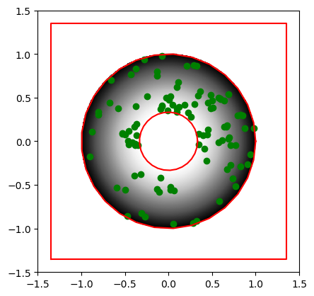

```python
simulation_index = 1

extent = [simulation_spatial_data[simulation_index]["extent"]["left"],
          simulation_spatial_data[simulation_index]["extent"]["right"],
         simulation_spatial_data[simulation_index]["extent"]["bot"],
         simulation_spatial_data[simulation_index]["extent"]["top"]]
plt.imshow(simulation_spatial_data[simulation_index]["crowders"],extent = extent,cmap = "Greys")


plt.imshow(simulation_spatial_data[simulation_index]["nucleus distance"],extent = extent,cmap = "Greys")

plt.plot(simulation_spatial_data[simulation_index]["cell"].x,simulation_spatial_data[simulation_index]["cell"].y,color = "red")
plt.plot(simulation_spatial_data[simulation_index]["nucleus"].x,simulation_spatial_data[simulation_index]["nucleus"].y,color = "red")
plt.plot(simulation_spatial_data[simulation_index]["box"].x,simulation_spatial_data[simulation_index]["box"].y,color = "red")

plt.scatter(simulation_spatial_data[simulation_index]["particles"].x,simulation_spatial_data[simulation_index]["particles"].y,color = "green")

plt.show()
```

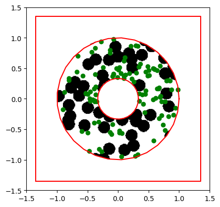

```python
simulation_index = 1
extent = [simulation_spatial_data[simulation_index]["extent"]["left"],
          simulation_spatial_data[simulation_index]["extent"]["right"],
         simulation_spatial_data[simulation_index]["extent"]["bot"],
         simulation_spatial_data[simulation_index]["extent"]["top"]]
plt.imshow(simulation_spatial_data[simulation_index]["crowders"],extent = extent,cmap = "Greys")

plt.plot(simulation_spatial_data[simulation_index]["cell"].x,simulation_spatial_data[simulation_index]["cell"].y,color = "red")
plt.plot(simulation_spatial_data[simulation_index]["nucleus"].x,simulation_spatial_data[simulation_index]["nucleus"].y,color = "red")
plt.plot(simulation_spatial_data[simulation_index]["box"].x,simulation_spatial_data[simulation_index]["box"].y,color = "red")

plt.scatter(simulation_spatial_data[simulation_index]["particles"].x,simulation_spatial_data[simulation_index]["particles"].y,color = "green")

plt.show()
```

## Stich together particle locations and images

```python
import numpy as np


aggregated_data = {}

# Create each row by horizontally stacking 3 images

for image in ["crowders","nucleus distance"]:
    row1 = np.hstack((simulation_spatial_data[6][image], simulation_spatial_data[7][image], simulation_spatial_data[8][image]))
    row2 = np.hstack((simulation_spatial_data[3][image], simulation_spatial_data[4][image], simulation_spatial_data[5][image]))
    row3 = np.hstack((simulation_spatial_data[0][image], simulation_spatial_data[1][image], simulation_spatial_data[2][image]))

    aggregated_data[image] =  np.vstack((row1, row2, row3))

aggregated_data["resolution"] = resolution

aggregated_data["extent"] = {}

aggregated_data["extent"] = {"left": -half_dimension_length,
                     "right" :-half_dimension_length + 3*dimension_length,
                     "bot" :  -half_dimension_length,
                     "top" :   -half_dimension_length + 3*dimension_length,
                    }

aggregated_data_extent = [aggregated_data["extent"][direction] for direction in ["left","right","bot","top"]]
```

```python
shifts_vector = np.array([0,dimension_length,2*dimension_length ])
x_shifts_v, y_shifts_v = np.meshgrid(shifts_vector, shifts_vector)
```

```python
for component in ["cell","nucleus","box"]:
    aggregated_data[component] = []
    for ssd, x_shift, y_shift in zip(simulation_spatial_data, x_shifts_v.flatten(),y_shifts_v.flatten()):
        component_copy = SpatialData(ssd[component].x,ssd[component].y)
        component_copy.shift(x_shift,y_shift)
        aggregated_data[component].append(component_copy)


aggregated_data["particles"] = SpatialData([],[])
for ssd, x_shift, y_shift in zip(simulation_spatial_data, x_shifts_v.flatten(),y_shifts_v.flatten()):
    component_copy = SpatialData(ssd["particles"].x,ssd["particles"].y)
    component_copy.shift(x_shift,y_shift)
    aggregated_data["particles"].x = aggregated_data["particles"].x + component_copy.x
    aggregated_data["particles"].y = aggregated_data["particles"].y + component_copy.y
```

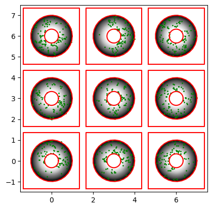

```python
plt.imshow(aggregated_data["nucleus distance"],cmap = "Greys",extent = aggregated_data_extent)

for component in ["cell","nucleus","box"]:
    for spatial_data in aggregated_data[component]:
        plt.plot(spatial_data.x,spatial_data.y,color = "red")

plt.scatter(aggregated_data["particles"].x,aggregated_data["particles"].y,color = "green",s = 1)
plt.show()
```

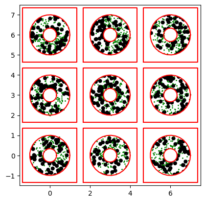

```python
plt.imshow(aggregated_data["crowders"],cmap = "Greys",extent = aggregated_data_extent)

for component in ["cell","nucleus","box"]:
    for spatial_data in aggregated_data[component]:
        plt.plot(spatial_data.x,spatial_data.y,color = "red")

plt.scatter(aggregated_data["particles"].x,aggregated_data["particles"].y,color = "green",s = 1)


plt.show()
```

```python
domain_polygons = []
for cell,nucleus in zip(aggregated_data["cell"],aggregated_data["nucleus"]):
    p1 = shapely.geometry.Polygon(zip(nucleus.x, nucleus.y))
    p2 = shapely.geometry.Polygon(zip(cell.x, cell.y))
    domain_polygons.append(shapely.geometry.Polygon(p2.exterior.coords, [p1.exterior.coords]))


contour_dicitonary = {'ID': np.arange(1,10).tolist(), 'geometry': domain_polygons}
gdf_polygons = gpd.GeoDataFrame(contour_dicitonary)  # Using WGS84 CRS as an example
gdf_polygons.to_file("../data/synthetic_data/diffusion_in_crowded_enviroment/domain.geojson", driver="GeoJSON",crs=None)

box_polygons = [shapely.geometry.Polygon(zip(box.x,box.y)) for box in aggregated_data["box"] ]
gdf = gpd.GeoDataFrame(geometry=box_polygons)
gdf.to_file("../data/synthetic_data/diffusion_in_crowded_enviroment/meshbox.geojson", driver="GeoJSON",crs=None)

gdf = gpd.GeoDataFrame({'id': np.arange(len(aggregated_data["particles"].x)).tolist(),}, geometry=gpd.points_from_xy(aggregated_data["particles"].x, aggregated_data["particles"].y), crs=None)
gdf.to_file("../data/synthetic_data/diffusion_in_crowded_enviroment/particles.geojson", driver="GeoJSON",crs=None)
```

Now we want to stitch the simulations together in a single geographical area, in order to do fith the model on all of them

```python
transform = rasterio.transform.from_origin(aggregated_data["extent"]["left"],
                                           aggregated_data["extent"]["top"],
                                           aggregated_data["resolution"],
                                           aggregated_data["resolution"])

with rasterio.open("../data/synthetic_data/diffusion_in_crowded_enviroment/crowders.tif",
                   'w',
                   driver='GTiff',
                   height=aggregated_data["crowders"].shape[0], width=aggregated_data["crowders"].shape[1],
                   count=1,
                   dtype= (aggregated_data["crowders"].dtype).name,
                    crs= None,
                   transform=transform) as dst: dst.write(aggregated_data["crowders"], 1)

with rasterio.open("../data/synthetic_data/diffusion_in_crowded_enviroment/nucleus_distance.tif",
                   'w',
                   driver='GTiff',
                   height=aggregated_data["nucleus distance"].shape[0], width=aggregated_data["nucleus distance"].shape[1],
                   count=1,
                   dtype= (aggregated_data["nucleus distance"].dtype).name,
                    crs= None,
                   transform=transform) as dst: dst.write(aggregated_data["nucleus distance"], 1)
```